# Simulation, power, and logistic regression

Peter Ralph

22 January 2018 – Advanced Biological Statistics

## Outline

1. Uses of simulation
2. … applied to the hierarchical model.
3. Posterior predictive sampling.
4. Shrinkage: sharing information
5. Predicting binary outcomes from quantitative variables: Bayesian logistic regression

# Back to baseball

## From last time:

$$\begin{aligned}
Z_i &\sim \Binom(N_i, \theta_i) \\
\theta_i &\sim \Beta(\mu_{p_i} \kappa_{p_i}, (1-\mu_{p_i})\kappa_{p_i}) \\
\mu &\sim \Beta(1, 1) \\
\kappa_p &\sim \Gam(0.1, 0.1) .
\end{aligned}$$

```r
pos_model <- "
data {
    int N;   // number of players
    int hits[N];
    int at_bats[N];
    int npos; // number of positions
    int position[N];
}
parameters {
    real<lower=0, upper=1> theta[N];
    real<lower=0, upper=1> mu[npos];
    real<lower=0> kappa[npos];
}
model {
    real alpha;
    real beta;
    hits ~ binomial(at_bats, theta);
    for (i in 1:N) {
        alpha = mu[position[i]] * kappa[position[i]];
        beta = (1 - mu[position[i]]) * kappa[position[i]];
        theta[i] ~ beta(alpha, beta);
    }
    mu ~ beta(1,1);
    kappa ~ gamma(0.1,0.1);
} "
```

```r
batting <- read.csv("BattingAverage.csv", header=TRUE)
system.time(pos_fit <- stan(model_code=pos_model, chains=3, iter=100,
                            data=list(N=nrow(batting),
                                      hits=batting$Hits,
                                      at_bats=batting$AtBats,
                                      npos=nlevels(batting$PriPos),
                                      position=as.numeric(batting$PriPos))))
```

```
##    user  system elapsed
##  36.542   0.699  63.372
```

## Diagnostics

```r
print(pos_fit, pars=c("mu", "kappa"))
```

```
## Inference for Stan model: db775bca82d7fc39d379745fb39b0819.
## 3 chains, each with iter=100; warmup=50; thin=1;
## post-warmup draws per chain=50, total post-warmup draws=150.
##
##            mean se_mean    sd  2.5%    25%    50%    75%  97.5% n_eff Rhat
## mu[1]      0.25    0.00  0.01  0.24   0.25   0.25   0.26   0.26   150 0.99
## mu[2]      0.25    0.00  0.01  0.24   0.25   0.25   0.25   0.26   150 1.01
## mu[3]      0.26    0.00  0.01  0.24   0.25   0.26   0.26   0.27   150 0.99
## mu[4]      0.24    0.00  0.01  0.23   0.24   0.24   0.24   0.25   150 1.00
## mu[5]      0.26    0.00  0.01  0.25   0.25   0.26   0.26   0.27   150 1.01
## mu[6]      0.25    0.00  0.01  0.24   0.25   0.25   0.25   0.26   150 0.98
## mu[7]      0.13    0.00  0.01  0.12   0.13   0.13   0.13   0.15    32 1.09
## mu[8]      0.26    0.00  0.01  0.25   0.25   0.26   0.26   0.27   150 1.00
## mu[9]      0.25    0.00  0.01  0.23   0.24   0.25   0.25   0.26   143 0.99
## kappa[1] 108.37    1.88 23.05 67.67  93.56 107.63 122.63 158.14   150 1.04
## kappa[2] 104.02    1.76 21.53 67.90  88.54 100.81 118.35 158.38   150 0.99
## kappa[3] 100.08    1.77 21.70 60.05  85.40  99.20 112.81 148.72   150 0.99
## kappa[4]  93.96    2.68 18.69 60.14  80.98  93.51 105.65 134.80    49 1.04
## kappa[5] 100.10    2.87 23.01 66.84  85.37  95.12 113.20 157.17    64 1.00
## kappa[6] 109.72    1.85 20.04 74.22  97.73 108.44 121.05 151.00   117 0.99
## kappa[7]  58.73    7.73 15.33 36.00  47.45  58.14  67.02  93.41     4 1.24
## kappa[8] 117.57    2.09 25.64 74.24 100.18 114.65 132.04 170.47   150 1.03
## kappa[9]  90.86    2.18 24.45 53.10  72.15  89.07 102.94 147.77   125 1.02
##
## Samples were drawn using NUTS(diag_e) at Tue Jan 23 09:36:38 2018.
## For each parameter, n_eff is a crude measure of effective sample size,
## and Rhat is the potential scale reduction factor on split chains (at
## convergence, Rhat=1).
```

Is it mixing?

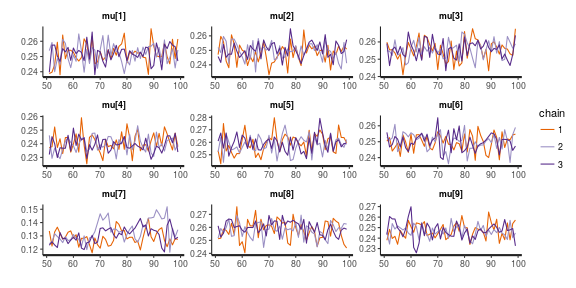

```r
stan_trace(pos_fit, pars="mu")
```

## Run longer!

```r
system.time(pos_fit <- stan(model_code=pos_model, chains=3, iter=1000,
                            control=list(max_treedepth=15),
                            data=list(N=nrow(batting),
                                      hits=batting$Hits,
                                      at_bats=batting$AtBats,
                                      npos=nlevels(batting$PriPos),
                                      position=as.numeric(batting$PriPos))))
```

```
##    user  system elapsed
##   0.693   0.031 461.301
```

```r
print(pos_fit, pars=c("mu", "kappa"))
```

```
## Inference for Stan model: db775bca82d7fc39d379745fb39b0819.
## 3 chains, each with iter=1000; warmup=500; thin=1;
## post-warmup draws per chain=500, total post-warmup draws=1500.
##
##            mean se_mean    sd  2.5%    25%    50%    75%  97.5% n_eff Rhat
## mu[1]      0.25    0.00  0.01  0.24   0.25   0.25   0.26   0.26  1069 1.00
## mu[2]      0.25    0.00  0.01  0.24   0.24   0.25   0.25   0.26   848 1.00
## mu[3]      0.26    0.00  0.01  0.24   0.25   0.26   0.26   0.27  1032 1.00
## mu[4]      0.24    0.00  0.01  0.23   0.23   0.24   0.24   0.25   622 1.00
## mu[5]      0.26    0.00  0.01  0.24   0.25   0.26   0.26   0.27   725 1.00
## mu[6]      0.25    0.00  0.01  0.24   0.25   0.25   0.25   0.26   725 1.00
## mu[7]      0.13    0.00  0.01  0.12   0.12   0.13   0.13   0.14   155 1.01
## mu[8]      0.26    0.00  0.01  0.25   0.25   0.26   0.26   0.27  1134 1.01
## mu[9]      0.25    0.00  0.01  0.23   0.24   0.25   0.25   0.26   902 1.00
## kappa[1] 111.46    0.80 22.73 72.21  95.14 109.91 126.23 159.03   801 1.00
## kappa[2] 104.10    0.83 24.31 63.39  86.72 101.64 118.19 160.01   859 1.00
## kappa[3]  98.40    0.69 21.63 62.82  82.72  96.13 112.30 144.99   974 1.01
## kappa[4]  95.30    0.84 20.67 60.16  80.97  93.37 107.86 140.67   601 1.00
## kappa[5] 101.80    0.84 22.88 61.50  85.47 100.64 116.86 148.69   742 1.00
## kappa[6] 106.34    0.78 21.32 69.56  91.43 104.68 118.46 155.97   743 1.01
## kappa[7]  56.29    1.16 13.21 35.00  46.82  54.85  64.32  85.75   129 1.01
## kappa[8] 119.73    1.00 27.64 73.47 100.23 118.23 135.95 180.19   761 1.00
## kappa[9]  95.69    0.91 22.74 59.07  79.80  93.10 109.56 148.44   619 1.00
##
## Samples were drawn using NUTS(diag_e) at Tue Jan 23 09:44:21 2018.
## For each parameter, n_eff is a crude measure of effective sample size,
## and Rhat is the potential scale reduction factor on split chains (at
## convergence, Rhat=1).
```

Is it mixing?

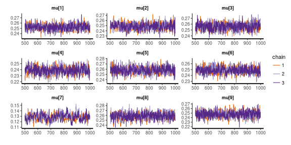

```r
stan_trace(pos_fit, pars="mu")
```

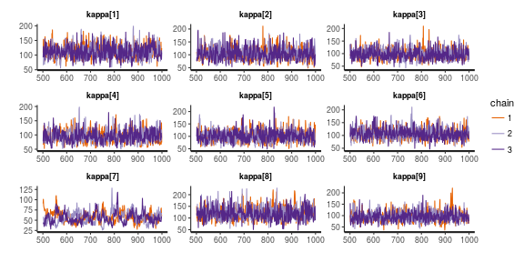

```r
stan_trace(pos_fit, pars="kappa")
```

## Let’s look at the results!

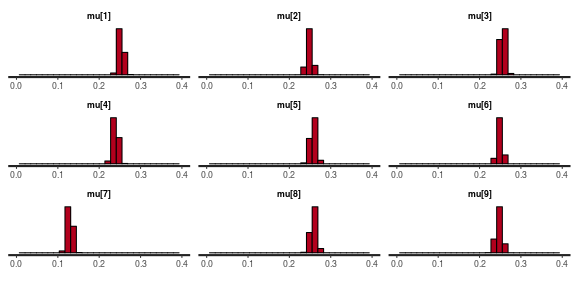

```r
stan_hist(pos_fit, pars="mu", bins=30) + xlim(0, 0.4)
```

I like labels.

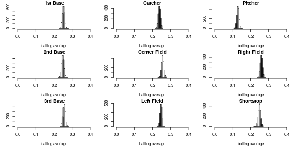

```r
param_samples <- extract(pos_fit)
layout(matrix(1:9, ncol=3))
par(mar=c(4,3,1,1)+.1)
for (k in 1:9) {
    hist(param_samples$mu[,k], main=levels(batting$PriPos)[k],
         xlim=c(0, 0.4), xlab='batting average', ylab=expression(mu))
}
```

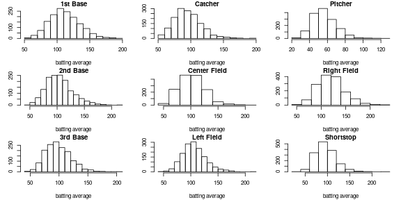

```r
layout(matrix(1:9, ncol=3))
par(mar=c(4,3,1,1)+.1)
for (k in 1:9) {
    hist(param_samples$kappa[,k], main=levels(batting$PriPos)[k],
         xlab='batting average', ylab=expression(kappa))
}
```

## What else do you want to know?

About
$$\begin{aligned}
\theta_i &: \text{individual $i$ batting averages} \\
\mu &: \text{position $p$ mean batting averages} \\
\kappa_p &: \text{position $p$ variability of batting averages}
\end{aligned}$$

## Do positions with more at-bats have higher batting averages?

To answer this, let’s find the posterior distribution of the difference in means ($\mu_p$) between two positions, 1st base, who have a lot of at-bats, and pitchers, who don’t.

To do this, we’ll use the random samples obtained with `extract()`.

```r
first_base_col <- which(levels(batting$PriPos) == "1st Base")
pitcher_col <- which(levels(batting$PriPos) == "Pitcher")
mu_diff <- param_samples$mu[,first_base_col] - param_samples$mu[,pitcher_col]
```

The posterior mean of $\mu_\text{1st base} - \mu_\text{pitcher}$ is 0.1235826; and the posterior SD is 0.008477. This is a very large difference, and we are very certain of this - our estimate of a 95% credible interval for the difference is from 0.1071786 to 0.1401361.

## What position has the most consistent batting average?

Find the posterior distribution of SDs of $\theta_i$s, separately by position.

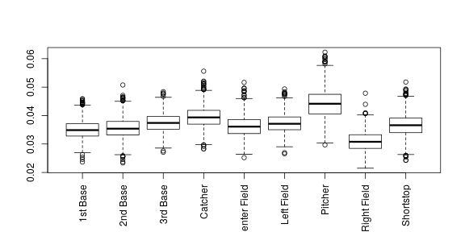

```r
colnames(pos_sds) <- levels(batting$PriPos)
boxplot(pos_sds, las=3)
```

# Stochastic minute

## Exponential, and Gamma

If $T \sim \Exp(\text{rate}=\lambda)$, then

$$\begin{aligned}
\P\{ T \in dt \} = \lambda e^{-\lambda t} dt .
\end{aligned}$$

1. $T$ can be any nonnegative real number.
2. $T$ is *memoryless*:
   $$\begin{aligned}
   \P\{ T > x + y \given T > x \} = \P\{ T > y \} .
   \end{aligned}$$
3. A machine produces $n$ widgets per second; each widget has probability $\lambda/n$ of being broken. The time until the first broken widget appears (in seconds) is approximately $\sim \Exp(\lambda)$.

If $S \sim \Gam(\text{shape}=\alpha, \text{rate}=\lambda)$, then

$$\begin{aligned}
\P\{ S \in dt \} = \frac{\alpha^\lambda}{\Gamma(\alpha)} t^{\alpha - 1} e^{-\lambda t} dt .
\end{aligned}$$

1. If $T_1, \ldots, T_k$ are independent $\Exp(\lambda)$, then $S = T_1 + \cdots + T_k$ is $\Gam(k, \lambda)$.
2. A machine produces $n$ widgets per second; each widget has probability $\lambda/n$ of being broken. The time until the $k^\text{th}$ broken widget appears (in seconds) is approximately $\sim \Gam(k, \lambda)$.

# Simulation

## Wouldn’t it be nice if we knew the truth?

**Discuss:**

Write down (on whiteboards) a procedure to simulate data that looks like the baseball data.

```r
batting$post_mean <- colMeans(param_samples$theta)
batting$fake_hits <- rbinom(nrow(batting),
                            size=batting$AtBats,
                            prob=batting$post_mean)
```

*Option 1:* By simulating draws from the posterior mean on $\theta$. we can check that our model is accurately describing the data - here we plot the real data against data simulated under the posterior mean $\theta$ values. They look similar, which is good.

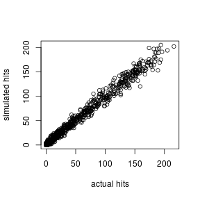

**But** if we want to know if we’re accurately estimating $\mu$ and $\theta$, then we have to start with them, and *simulate* $\theta$.

```r
post_mean_mu <- colMeans(param_samples$mu)
post_mean_kappa <- colMeans(param_samples$kappa)
names(post_mean_mu) <- names(post_mean_kappa) <- levels(batting$PriPos)
batting$sim_theta <- rbeta(nrow(batting),
                           shape1=post_mean_mu[batting$PriPos] *
                                   post_mean_kappa[batting$PriPos],
                           shape2=(1-post_mean_mu[batting$PriPos]) *
                                   post_mean_kappa[batting$PriPos])
batting$sim_theta_hits <- rbinom(nrow(batting),
                                 size=batting$AtBats,
                                 prob=batting$sim_theta)
```

Fit the model to the *simulated* data:

```r
sim_fit <- stan(model_code=pos_model, chains=3, iter=1000, control=list(max_treedepth=13),
                data=list(N=nrow(batting),
                          hits=batting$sim_theta_hits,
                          at_bats=batting$AtBats,
                          npos=nlevels(batting$PriPos),
                          position=as.numeric(batting$PriPos)))
```

Can we estimate $\mu$ and $\kappa$?

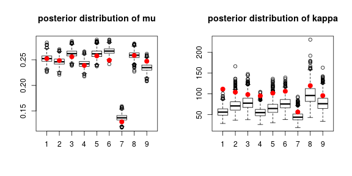

```r
sim_samples <- extract(sim_fit)
layout(t(1:2))
boxplot(sim_samples$mu, main="posterior distribution of mu")
points(1:9, post_mean_mu, col='red', pch=20, cex=2)
boxplot(sim_samples$kappa, main="posterior distribution of kappa")
points(1:9, post_mean_kappa, col='red', pch=20, cex=2)
```

## General questions with simulated data

1. Does my statistical inference method work?
2. Do the credible intervals contain the true value?

   (i.e., Is the method “well-calibrated”?)

   *They usually should.*
3. How wide are credible intervals, typically?

   This is (one kind of) **statistical power.**

# Posterior predictive sampling

## How to choose parameter values for simulation?

It depends, but one good choice is *from the posterior distribution* - then you can see how the model behaves with data close to the real data.

This is known as **posterior predictive sampling**.

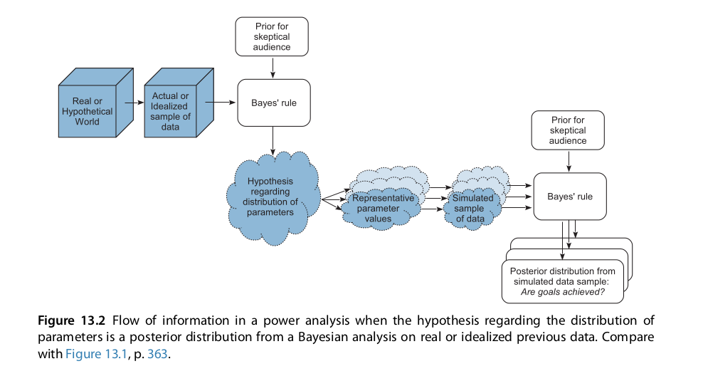

Kruschke figure 13.2: posterior predictive sampilng

# Sharing power // Shrinkage

## Example

Suppose that I have a large pot of coins that are all similar to each other. I flip each one ten times, and record the number of Heads. What is *each coin’s* probability of Heads?

- Treated *separately*, we would be very uncertain about each coin.
- Together, they should tell us very accurately what are *likely* values of $\theta$.
- This information can improve the estimate of each separate $\theta$.
- The more similar the coins are, the more information we gain.

## Shrinkage and baseball

Some players were at bat very few times. How does the information about their position affect our inference about their batting averages?

```r
batting$post_med <- colMedians(param_samples$theta)
batting$post_Q1 <- colQuantiles(param_samples$theta, probs=0.25)
batting$post_Q3 <- colQuantiles(param_samples$theta, probs=0.75)
pos_means <- colMeans(param_samples$mu)
names(pos_means) <- levels(batting$PriPos)
pos_means
```

```
##     1st Base     2nd Base     3rd Base      Catcher Center Field
##    0.2524944    0.2486243    0.2560179    0.2390597    0.2577180
##   Left Field      Pitcher  Right Field    Shortstop
##    0.2490896    0.1289117    0.2586441    0.2473216
```

Pitchers had posterior mean $\mu$ of 0.1289117

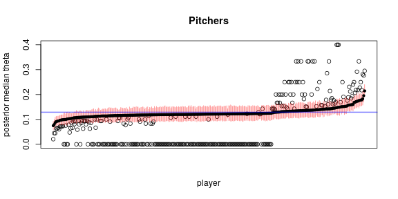

```r
with(subset(batting[order(batting$post_med),], PriPos=="Pitcher"), {
     plot(Hits / AtBats, main="Pitchers", xaxt='n', ylim=c(0, 0.4),
         xlab='player', ylab="posterior median theta");
     segments(x0=seq_along(Hits), y0=post_Q1, y1=post_Q3,
         col=adjustcolor('red',0.5));
     points(post_med, pch=20) })
abline(h=pos_means["Pitcher"], lwd=2, col=adjustcolor("blue", 0.5))
```

Catchers had posterior mean $\mu$ of 0.2390597

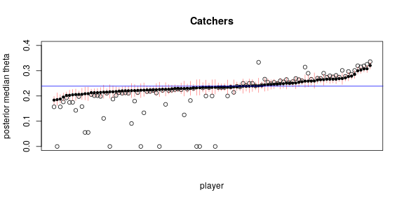

```r
with(subset(batting[order(batting$post_med),], PriPos=="Catcher"), {
     plot(Hits / AtBats, main="Catchers", xaxt='n', ylim=c(0, 0.4),
         xlab='player', ylab="posterior median theta");
     segments(x0=seq_along(Hits), y0=post_Q1, y1=post_Q3,
         col=adjustcolor('red',0.5));
     points(post_med, pch=20) })
abline(h=pos_means["Catcher"], lwd=2, col=adjustcolor("blue", 0.5))
```

## Is shrinkage here a good idea?

With *simulated data*, compare median absolute error for

- posterior mean $\theta_i$
- empirical batting average

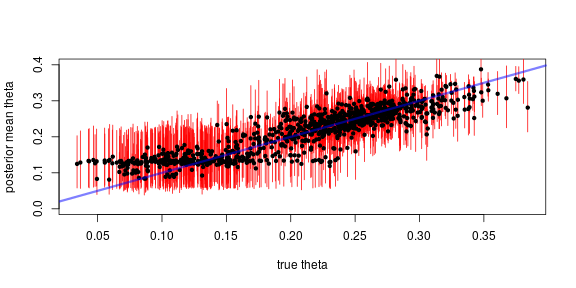

```r
post_sim_theta <- colMeans(sim_samples$theta)
plot(batting$sim_theta, post_sim_theta, type='n', xlab="true theta", ylab="posterior mean theta", ylim=c(0,0.4))
segments(x0=batting$sim_theta,  col='red',
         y0=colQuantiles(sim_samples$theta, probs=0.05),
         y1=colQuantiles(sim_samples$theta, probs=0.95))
points(batting$sim_theta, post_sim_theta, pch=20)
abline(0, 1, lwd=3, col=adjustcolor('blue', 0.5))
```

Did we do better?

The mean absolute difference between the *truth* and

- posterior mean: 0.0255111
- empirical batting average (hits/at bats): 0.0895372

# Logistic regression, a.k.a. metric predictors

## Motivation

There’s a good bit more information available about the baseball players.

```r
batplus <- read.csv("BattingAveragePlus.csv")
head(batplus)
```

```
##             Player     PriPos Hits AtBats PlayerNumber PriPosNumber
## 1 Aaron Cunningham Left Field   17     97          198            7
## 2     Aaron Harang    Pitcher    4     56          360            1
## 3       Aaron Hill   2nd Base  184    609          394            4
## 4     Aaron Laffey    Pitcher    0      1          482            1
## 5       Aaron Loup    Pitcher    0      1          522            1
## 6        Adam Dunn   1st Base  110    539          242            3
##    playerID weight height bats birthYear      debut  finalGame
## 1 cunniaa01    215     71    R      1986 2008-08-31 2012-07-24
## 2 haranaa01    260     79    R      1978 2002-05-25 2015-10-03
## 3  hillaa01    200     71    R      1982 2005-05-20 2016-10-01
## 4 laffeaa01    190     71    L      1985 2007-08-04 2015-07-31
## 5  loupaa01    210     71    L      1987 2012-07-14 2016-09-30
## 6  dunnad01    285     78    L      1979 2001-07-20 2014-09-28
```

Is batting average predicted by weight and height?

1. Each player has their own batting avg, $\theta_i$.
2. Batting averages tend to be different for different positions.
3. After accounting for position ($p_i$), $\theta$ varies with height ($h_i$) and/or weight ($w_i$).

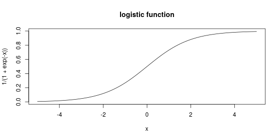

$$\begin{aligned}
Z_i &\sim \Binom(N_i, \theta_i) \\
\theta_i &= \Beta(\mu_i \kappa_{p_i}, (1-\mu_i) \kappa_{p_i}) \\
\mu_i &= \logistic(\gamma_{p_i} + \alpha_h h_i + \alpha_w w_i) \\
\kappa_p &\sim \Gam(0.1, 0.1) \\
\gamma_{p} &\sim \Normal(0, \sigma_\gamma) \\
\alpha_h &\sim \Normal(0, \sigma_h) \\
\alpha_w &\sim \Normal(0, \sigma_w) \\
\sigma_\gamma, \sigma_h, \sigma_w &\sim \Normal^+(0, 20)
\end{aligned}$$

## Stan

```r
logistic_model <- "
data {
    int N;   // number of players
    int hits[N];
    int at_bats[N];
    int npos; // number of positions
    int position[N];
    vector[N] height;
    vector[N] weight;
}
parameters {
    real<lower=0, upper=1> theta[N];
    vector[npos] gamma;
    real alpha_w;
    real alpha_h;
    vector<lower=0>[npos] kappa;
}
model {
    vector[N] mu;
    mu = inv_logit(gamma[position] + alpha_h * height + alpha_w * weight);
    theta ~ beta(mu .* kappa[position], (1-mu) .* kappa[position]);
    hits ~ binomial(at_bats, theta);
    kappa ~ gamma(0.1, 0.1);
    gamma ~ normal(0, 5);
    alpha_h ~ normal(0, 5);
    alpha_w ~ normal(0, 5);
} "
```

$$\begin{aligned}
Z_i &\sim \Binom(N_i, \theta_i) \\
\theta_i &= \Beta(\mu_i \kappa_{p_i}, (1-\mu_i) \kappa_{p_i}) \\
\mu_i &= \logistic(\gamma_{p_i} + \alpha_h h_i + \alpha_w w_i) \\
\kappa_p &\sim \Gam(0.1, 0.1) \\
\gamma_{p} &\sim \Normal(0, 5) \\
\alpha_h &\sim \Normal(0, 5) \\
\alpha_w &\sim \Normal(0, 5)
\end{aligned}$$

## New features

```r
logistic_model <- "
data {
    int N;   // number of players
    int hits[N];
    int at_bats[N];
    int npos; // number of positions
    int position[N];
    vector[N] height;
    vector[N] weight;
}
parameters {
    real<lower=0, upper=1> theta[N];
    vector[npos] gamma;
    real alpha_w;
    real alpha_h;
    vector<lower=0>[npos] kappa;
}
model {
    vector[N] mu;
    mu = inv_logit(gamma[position] + alpha_h * height + alpha_w * weight);
    theta ~ beta(mu .* kappa[position], (1-mu) .* kappa[position]);
    hits ~ binomial(at_bats, theta);
    kappa ~ gamma(0.1, 0.1);
    gamma ~ normal(0, 5);
    alpha_h ~ normal(0, 5);
    alpha_w ~ normal(0, 5);
} "
```

1. `vector[N] height;` instead of `real height[N];`: to allow `alpha_h * height`.
2. we will *center* and *scale* height and weight before passing to Stan
3. `x .* y` for component-wise multiplication

```r
scaled_height <- (batplus$height - mean(batplus$height))/sd(batplus$height)
scaled_weight <- (batplus$weight - mean(batplus$weight))/sd(batplus$weight)
system.time(logistic_fit <- stan(model_code=logistic_model, chains=3, iter=1000,
                               control=list(adapt_delta=0.9, max_treedepth=12),
                               data=list(N=nrow(batplus),
                                      hits=batplus$Hits,
                                      at_bats=batplus$AtBats,
                                      npos=nlevels(batplus$PriPos),
                                      position=as.numeric(batplus$PriPos),
                                      height=scaled_height,
                                      weight=scaled_weight) ))
```

```
##    user  system elapsed
##   0.824   0.558 194.307
```

```r
logistic_summary <- rstan::summary(logistic_fit)$summary
print(logistic_summary)
```

[output not shown]

[output cut: 2669 more lines]

[output not shown]

## Pitchers still don’t bat well

```
## ci_level: 0.8 (80% intervals)
```

```
## outer_level: 0.95 (95% intervals)
```

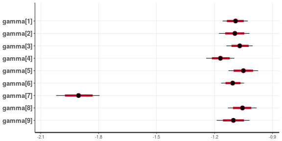

```r
stan_plot(logistic_fit, pars="gamma")
```

Recall the *mean* of $\theta_i$ is
$$\begin{aligned}
\mu_i = \frac{1}{1 + \exp(-\gamma_{p_i} - \alpha_h h_i - \alpha_w w_i)} .
\end{aligned}$$

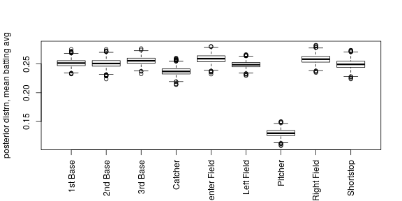

```r
gamma_samples <- rstan::extract(logistic_fit)$gamma
colnames(gamma_samples) <- levels(batplus$PriPos)
mu_samples <- 1/(1+exp(-gamma_samples))
boxplot(mu_samples, ylab="posterior distrn, mean batting avg", las=3)
```

## No effect of height or weight

```
## ci_level: 0.8 (80% intervals)
```

```
## outer_level: 0.95 (95% intervals)
```

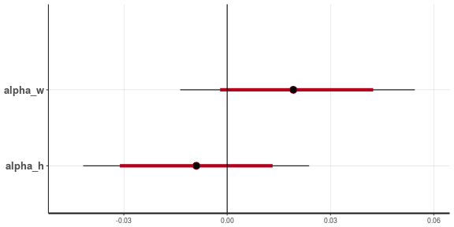

```r
stan_plot(logistic_fit, pars=c("alpha_w", "alpha_h")) + geom_vline(xintercept=0)
```

## Same $\theta$ as before?

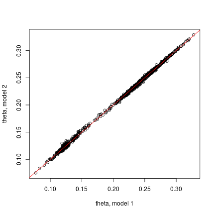

```r
new_post_theta <- colMeans(rstan::extract(logistic_fit)$theta)
old_post_theta <- batting$post_mean[match(batplus$Player, batting$Player)]
plot(old_post_theta, new_post_theta, xlab="theta, model 1", ylab="theta, model 2")
abline(0,1, col='red')
```

## Conclusions

1. We don’t have good evidence that batting average varies substantially with height or weight.
2. Changing the model from a Beta prior on class means to a logistic transform of a linear model did not substantially affect the results.